# Part V - Model Selection

This document is a part of the FACEIT Predictor Data Science Workflow.

In this notebook the Machine Learning Model is selected and its hyperparameters are tuned. Feature selection is also considered.

# Imports

```python
import warnings

# Data manipulation
import pandas as pd
import numpy as np

# Visualizations
import seaborn as sns
import matplotlib.pyplot as plt

# Scalers
from sklearn.preprocessing import StandardScaler

# Model selection and hyperparameter tuning
from sklearn.model_selection import train_test_split, cross_validate, RandomizedSearchCV

# Classifiers
from sklearn.discriminant_analysis import LinearDiscriminantAnalysis
from sklearn.ensemble import (
    AdaBoostClassifier,
    BaggingClassifier,
    ExtraTreesClassifier,
    GradientBoostingClassifier,
    RandomForestClassifier,
)
from sklearn.linear_model import RidgeClassifier, LogisticRegression
from sklearn.naive_bayes import BernoulliNB
from sklearn.neural_network import MLPClassifier
from sklearn.svm import LinearSVC
from sklearn.tree import DecisionTreeClassifier, ExtraTreeClassifier

from xgboost import XGBClassifier


# Stacking Classifier
from sklearn.ensemble import StackingClassifier

# Neural network libraries
import tensorflow as tf

# enable imports from parent directory
import sys
from pathlib import Path
sys.path.append(str(Path.cwd().parent.parent))

# import local modules
from src.utils.data_handlers import read_data
from src.notebooks.visualization import set_visualization_defaults
from src.notebooks.model_evaluation import print_metrics, print_metrics_nn, nn_compare_train_val

from IPython import get_ipython

ipython = get_ipython()

# autoreload extension
if "autoreload" not in ipython.extension_manager.loaded:
   %load_ext autoreload

# autoreload python modules
%autoreload 2
```

```python
warnings.filterwarnings("ignore")
```

```python
set_visualization_defaults()
```

```python
SEED = 15
```

# Load Processed Data

```python
data = read_data("processed", is_complete=True)
```

```python
dif_columns = [col for col in data.columns if col.startswith("dif_")]
team_features_columns = [col for col in data.columns if col.endswith("_A") or col.endswith("_B")]
data = data.drop(columns=team_features_columns)
```

```python
X = data.drop(columns=["winner", "_id"])
y = data["winner"]
```

Scaling data is crucial for performance of some algorithms.

```python
scaler = StandardScaler()
X = pd.DataFrame(scaler.fit_transform(X), columns=X.columns)
```

Split 70% of the data into the train dataset and the remaining 30% into the test dataset.

```python
X_train, X_test, y_train, y_test = train_test_split(X, y, test_size=0.3, random_state=SEED)
```

```python
print("X_train shape:", X_train.shape)
print("X_test shape:", X_test.shape)
```

```
X_train shape: (48241, 47)
X_test shape: (20676, 47)
```

# Baseline Model

```python
rf = RandomForestClassifier(random_state=SEED)
```

```python
rf.fit(X_train, y_train);
```

## Evaluation Fundamentals

To evaluate a classification model the five most common metrics are:

- Accuracy
- Precision
- Recall
- F1-Score
- AUC (Area under the ROC curve)

Since the dataset is balanced in regards to the target variable and there is no tangible distinction between type I and II errors, there is no need to look too much into Precision, Recall and consequently F1-score. The primary goals are to predict accurately the winner of the match and output a winning probability as close as possible to reality. Therefore, the two most important metrics are: **Accuracy** and **ROC-AUC** .

In any case, it must be ensured that the model is not considerably biased to predict one of the classes even with balanced team features values.

```python
scoring_metrics = ('accuracy', 'roc_auc')
```

Classification Report

|  | 0 | 1 | macro avg | weighted avg |
| --- | --- | --- | --- | --- |
| precision | 0.608358 | 0.612779 | 0.610568 | 0.610556 |
| recall | 0.632814 | 0.587858 | 0.610336 | 0.610466 |
| f1-score | 0.620345 | 0.600060 | 0.610202 | 0.610261 |
| support | 10398.000000 | 10278.000000 | 20676.000000 | 20676.000000 |

```
Train Accuracy: 0.6436		Test Accuracy: 0.6105
```

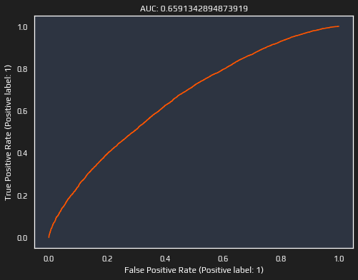

```python
print_metrics(rf, X_train, y_train, X_test, y_test)
```

```python
feature_importances_df = pd.DataFrame({"features":X_train.columns, "importances":rf.feature_importances_})
feature_importances_df.sort_values(by="importances", ascending=False).head(20)
```

|  | features | importances |
| --- | --- | --- |
| 3 | dif_mean_elo | 0.173811 |
| 29 | dif_mean_weighted_kd_by_elo_prev | 0.129270 |
| 28 | dif_mean_kd_prev | 0.112537 |
| 17 | dif_mean_rating_on_map | 0.101599 |
| 31 | dif_mean_rating_prev | 0.075097 |
| 15 | dif_mean_kd_on_map | 0.056093 |
| 14 | dif_mean_winrate_on_map | 0.042996 |
| 16 | dif_mean_multikills_score_on_map | 0.040892 |
| 10 | dif_mean_kd | 0.036979 |
| 30 | dif_mean_multikills_score_prev | 0.034920 |
| 18 | dif_mean_matches_map_preference | 0.034140 |
| 9 | dif_mean_winrate | 0.026863 |
| 20 | dif_mean_kd_map_preference | 0.023352 |
| 4 | dif_stddev_elo | 0.022999 |
| 12 | dif_mean_rating | 0.022720 |
| 13 | dif_mean_matches_on_map | 0.021249 |
| 8 | dif_mean_matches | 0.011725 |
| 19 | dif_mean_winrate_map_preference | 0.005215 |
| 36 | dif_mean_delta_elo_prev | 0.004476 |
| 22 | dif_mean_rating_map_preference | 0.004165 |

# Traditional Classifiers (Scikit-learn)

```python
clfs = {}
clfs["Linear Disc. Analysis"] = LinearDiscriminantAnalysis()
clfs["AdaBoost"] = AdaBoostClassifier(random_state=SEED)
clfs["Bagging"] = BaggingClassifier(random_state=SEED)
clfs["Extra Trees Ensemble"] = ExtraTreesClassifier(random_state=SEED)
clfs["Gradient Boosting"] = GradientBoostingClassifier(random_state=SEED)
clfs["Random Forest"] = RandomForestClassifier(random_state=SEED)
clfs["Ridge"] = RidgeClassifier(random_state=SEED)
clfs["Logistic Regression"] = LogisticRegression(random_state=SEED)
clfs["BernoulliNB"] = BernoulliNB()
clfs["Multi Layer Perceptron"] = MLPClassifier(random_state=SEED)
clfs["Linear SVC"] = LinearSVC(random_state=SEED)
clfs["Decision Tree"] = DecisionTreeClassifier(random_state=SEED)
clfs["Extra Tree"] = ExtraTreeClassifier(random_state=SEED)
clfs["XGB"] = XGBClassifier(random_state=SEED)


# Create dict for classifiers with feature_importances_ attribute
has_feature_importances = {
    "AdaBoost",
    "Extra Trees Ensemble",
    "Gradient Boosting",
    "Random Forest",
    "Decision Tree",
    "Extra Tree",
    "XGB",
}
```

```python
cv_folds = 5
```

```python
clfs_df, fts_imp_df = [], []

for name, clf in clfs.items():
    print("Fitting", name)

    index = pd.MultiIndex.from_product([[name], range(cv_folds)], names=["classifier", "fold_number"])
    output = cross_validate(clf, X_train, y_train, cv=cv_folds, scoring=scoring_metrics, return_train_score=True, return_estimator=True)

    clfs_df.append(pd.DataFrame(output, index=index))

    if name in has_feature_importances:
        fts_imp_df.append(pd.DataFrame([e.feature_importances_ for e in output["estimator"]], index=index, columns=X_train.columns))


clfs_df = pd.concat(clfs_df)
fts_imp_df = pd.concat(fts_imp_df)
```

```
Fitting Linear Disc. Analysis
Fitting AdaBoost
Fitting Bagging
Fitting Extra Trees Ensemble
Fitting Gradient Boosting
Fitting Random Forest
Fitting Ridge
Fitting Logistic Regression
Fitting BernoulliNB
Fitting Multi Layer Perceptron
Fitting Linear SVC
Fitting Decision Tree
Fitting Extra Tree
Fitting XGB
```

```python
ordered_clfs_df = clfs_df.groupby(by="classifier").median().sort_values(by="test_accuracy", ascending=False)
ordered_clfs_df
```

| classifier | fit_time | score_time | test_accuracy | train_accuracy | test_roc_auc | train_roc_auc |
| --- | --- | --- | --- | --- | --- | --- |
| Linear SVC | 14.923066 | 0.010997 | 0.616915 | 0.617495 | 0.666785 | 0.667396 |
| Logistic Regression | 0.610504 | 0.008974 | 0.616294 | 0.617677 | 0.667049 | 0.667516 |
| Linear Disc. Analysis | 0.404763 | 0.010971 | 0.616190 | 0.616822 | 0.666460 | 0.667217 |
| Ridge | 0.071800 | 0.010000 | 0.616190 | 0.616899 | 0.666456 | 0.667217 |
| Gradient Boosting | 42.591141 | 0.042885 | 0.612355 | 0.632680 | 0.661426 | 0.690299 |
| AdaBoost | 8.174134 | 0.233382 | 0.608624 | 0.617900 | 0.656050 | 0.668898 |
| Random Forest | 19.582670 | 0.539526 | 0.599295 | 1.000000 | 0.646254 | 1.000000 |
| Extra Trees Ensemble | 8.089330 | 0.812828 | 0.596289 | 1.000000 | 0.637997 | 1.000000 |
| BernoulliNB | 0.049867 | 0.024928 | 0.591522 | 0.590625 | 0.628006 | 0.626591 |
| XGB | 7.347345 | 0.083776 | 0.591107 | 0.798585 | 0.634214 | 0.889401 |
| Multi Layer Perceptron | 56.434646 | 0.034534 | 0.582193 | 0.697251 | 0.617389 | 0.770668 |
| Bagging | 14.166089 | 0.108713 | 0.570585 | 0.984479 | 0.599177 | 0.999010 |
| Decision Tree | 2.422523 | 0.014960 | 0.538454 | 1.000000 | 0.538440 | 1.000000 |
| Extra Tree | 0.099733 | 0.017917 | 0.531613 | 1.000000 | 0.531619 | 1.000000 |

```python
# 'Ignore' fold number index
classifiers_indexes = clfs_df.index.get_level_values(level=0)
```

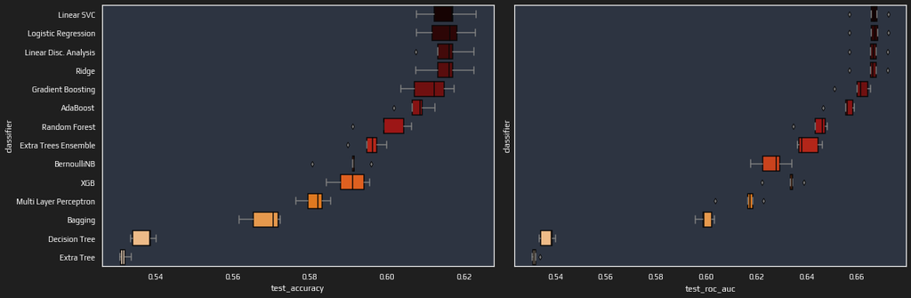

```python
fig, (ax1, ax2) = plt.subplots(1,2, figsize=(18,6), sharey=True)
styling_props = {"whiskerprops":{"color":"gray"}, "capprops":{"color":"gray"}, "flierprops":{"markerfacecolor":"gray"}}

sns.boxplot(x=clfs_df.test_accuracy, y=classifiers_indexes, order=ordered_clfs_df.index, ax=ax1, palette="gist_heat", **styling_props)
sns.boxplot(x=clfs_df.test_roc_auc, y=classifiers_indexes, order=ordered_clfs_df.index, ax=ax2, palette="gist_heat", **styling_props)
plt.tight_layout()
```

```python
ordered_fts_imp_df = fts_imp_df.median().sort_values(ascending=False)
```

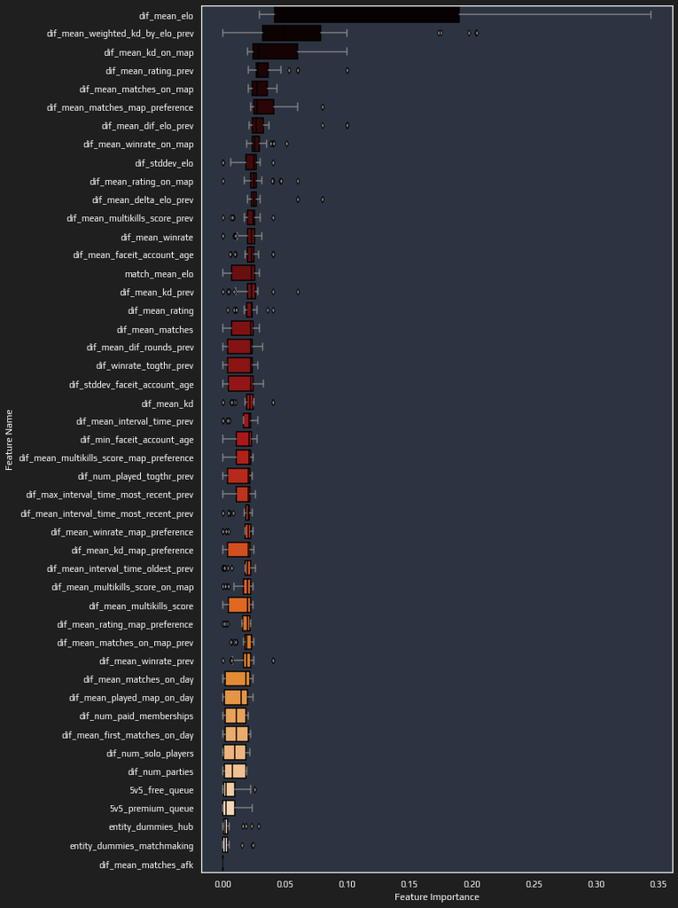

```python
plt.figure(figsize=(12,16))
ax = sns.boxplot(
    data=fts_imp_df.melt(),
    y="variable",
    x="value",
    order=ordered_fts_imp_df.index,
    palette="gist_heat",
    **styling_props)

ax.set_ylabel("Feature Name")
ax.set_xlabel("Feature Importance")
plt.tight_layout()
```

## Hyperparameter Tuning

Selected algorithms to perform hyperparameter tuning:

- Linear SVC
- Ridge
- Linear Discriminant Analysis
- Logistic Regression
- Gradient Boosting
- AdaBoost
- Random Forest
- XGB

```python
selected_clfs = []
selected_clfs.append({
    "name": "Linear SVC",
    "model": LinearSVC(random_state=SEED),
    "params": {
        "penalty": ["l1", "l2"],
        "loss": ["hinge", "squared_hinge"],
        "C":  [0.1, 1, 10, 100]
    }
})

selected_clfs.append({
    "name": "Ridge",
    "model": RidgeClassifier(random_state=SEED),
    "params": {
        "alpha": [0.1, 0.2, 0.3, 0.4, 0.5, 0.6, 0.7, 0.8, 0.9, 1.0]
    }
})

selected_clfs.append({
    "name": "Linear Disc Analysis",
    "model": LinearDiscriminantAnalysis(),
    "params": {
        'solver': ['svd', 'lsqr', 'eigen'],
        'shrinkage': np.arange(0, 1, 0.01)
    }
})

selected_clfs.append({
    "name": "Logistic Regression",
    "model": LogisticRegression(random_state=SEED),
    "params": {
        "penalty": ['l1', 'l2', 'elasticnet', None],
        "solver": ['newton-cg', 'lbfgs', 'liblinear', 'sag', 'saga'],
        "C": [100, 10, 1.0, 0.1, 0.01]
    }
})

selected_clfs.append({
    "name": "Gradient Boosting",
    "model": GradientBoostingClassifier(random_state=SEED),
    "params": {
        "n_estimators": [10, 100],
        "learning_rate": [0.01, 0.1],
        "min_samples_split": np.arange(0, 0.25, 0.03),
        "min_samples_leaf": np.arange(0, 0.25, 0.03),
        "max_depth": range(5, 16, 2),
        "max_features": range(7, 30, 3),
        "subsample": [0.7, 0.8, 0.9, 1]
    }
})

selected_clfs.append({
    "name": "AdaBoost",
    "model": AdaBoostClassifier(random_state=SEED),
    "params": {
        "n_estimators": [10, 50, 100, 200, 500, 1000],
        "learning_rate": [0.0001, 0.005, 0.01, 0.1, 1],
        "algorithm": ["SAMME", "SAMME.R"]
    }
})

selected_clfs.append({
    "name": "Random Forest",
    "model": RandomForestClassifier(random_state=SEED),
    "params": {
        "criterion": ['gini', 'entropy'],
        "n_estimators": [20, 50, 100, 150],
        "max_features": ["log2", "sqrt"],
        "min_samples_split": np.arange(0.01, 0.07, 0.01),
        "min_samples_leaf": np.arange(0.01, 0.07, 0.01),
    }
})

selected_clfs.append({
    "name": "XGB",
    "model": XGBClassifier(random_state=SEED),
    "params": {
        "learning_rate": [0.001, 0.005, 0.01, 0.05],
        "n_estimators": [50, 100, 200, 500, 1000],
        'max_depth': range(5, 10, 2),
        'min_child_weight': range(1, 10, 2),
        "subsample": [0.7, 0.8, 0.9, 1],
        'colsample_bytree': [0.6, 0.7, 0.8, 0.9],
        'reg_alpha': [0, 0.001, 0.005, 0.01, 0.05],
        'gamma': [0, 0.1, 0.2, 0.3, 0.4]
    }
})
```

```python
hyp_searches = {}
for alg_data in selected_clfs:
    print("Hyperparameter tuning of", alg_data["name"])

    hyp_search = RandomizedSearchCV(
            estimator=alg_data["model"],
            param_distributions=alg_data["params"],
            n_iter=10,
            cv=cv_folds,
            scoring=scoring_metrics,
            refit='roc_auc',
            n_jobs=-1,
            return_train_score=True,
            random_state=SEED,
            verbose=1)
    hyp_search.fit(X_train, y_train)
    hyp_searches[alg_data["name"]] = hyp_search
```

```
Hyperparameter tuning of Linear SVC
Fitting 5 folds for each of 10 candidates, totalling 50 fits
Hyperparameter tuning of Ridge
Fitting 5 folds for each of 10 candidates, totalling 50 fits
Hyperparameter tuning of Linear Disc Analysis
Fitting 5 folds for each of 10 candidates, totalling 50 fits
Hyperparameter tuning of Logistic Regression
Fitting 5 folds for each of 10 candidates, totalling 50 fits
Hyperparameter tuning of Gradient Boosting
Fitting 5 folds for each of 10 candidates, totalling 50 fits
Hyperparameter tuning of AdaBoost
Fitting 5 folds for each of 10 candidates, totalling 50 fits
Hyperparameter tuning of Random Forest
Fitting 5 folds for each of 10 candidates, totalling 50 fits
Hyperparameter tuning of XGB
Fitting 5 folds for each of 10 candidates, totalling 50 fits
```

```python
clfs_df, fts_imp_df = [], []

for name, gs in hyp_searches.items():
    best_estimator = gs.best_estimator_

    index = pd.MultiIndex.from_product([[name], range(cv_folds)], names=["classifier", "fold_number"])
    output = cross_validate(best_estimator, X_train, y_train, cv=cv_folds, scoring=scoring_metrics, return_train_score=True, return_estimator=True)

    clfs_df.append(pd.DataFrame(output, index=index))

    if name in has_feature_importances:
        fts_imp_df.append(pd.DataFrame([e.feature_importances_ for e in output["estimator"]], index=index, columns=X_train.columns))
```

```python
clfs_df = pd.concat(clfs_df)
fts_imp_df = pd.concat(fts_imp_df)
```

```python
ordered_clfs_df = clfs_df.groupby(by="classifier").median().sort_values(by="test_accuracy", ascending=False)
ordered_clfs_df
```

| classifier | fit_time | score_time | test_accuracy | train_accuracy | test_roc_auc | train_roc_auc |
| --- | --- | --- | --- | --- | --- | --- |
| Linear SVC | 14.013744 | 0.014410 | 0.616294 | 0.617184 | 0.666694 | 0.667377 |
| Logistic Regression | 0.860803 | 0.011952 | 0.616294 | 0.617677 | 0.667049 | 0.667516 |
| Ridge | 0.073473 | 0.011935 | 0.616190 | 0.616899 | 0.666456 | 0.667217 |
| Linear Disc Analysis | 0.229535 | 0.014252 | 0.614635 | 0.615604 | 0.663614 | 0.662837 |
| Gradient Boosting | 34.321417 | 0.103722 | 0.614221 | 0.638510 | 0.662329 | 0.694550 |
| XGB | 26.964798 | 0.271276 | 0.611526 | 0.681289 | 0.663786 | 0.754979 |
| AdaBoost | 20.051618 | 0.651948 | 0.606551 | 0.621253 | 0.655765 | 0.675039 |
| Random Forest | 51.322514 | 1.276619 | 0.599502 | 0.601664 | 0.639445 | 0.643255 |

```python
# 'Ignore' fold number index
classifiers_indexes = clfs_df.index.get_level_values(level=0)
```

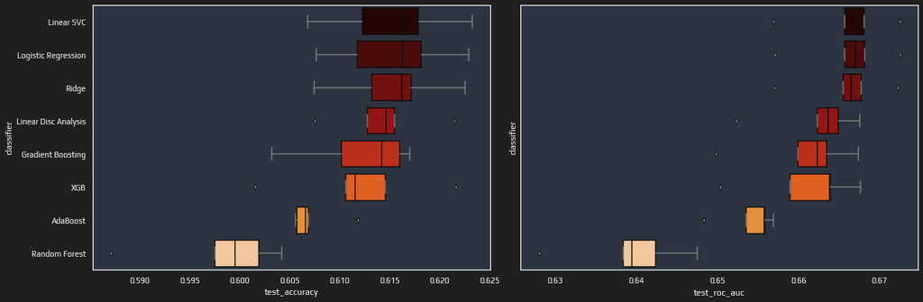

```python
fig, (ax1, ax2) = plt.subplots(1,2, figsize=(18,6), sharey=True)
styling_props = {"whiskerprops":{"color":"gray"}, "capprops":{"color":"gray"}, "flierprops":{"markerfacecolor":"gray"}}

sns.boxplot(x=clfs_df.test_accuracy, y=classifiers_indexes, order=ordered_clfs_df.index, ax=ax1, palette="gist_heat", **styling_props)
sns.boxplot(x=clfs_df.test_roc_auc, y=classifiers_indexes, order=ordered_clfs_df.index, ax=ax2, palette="gist_heat", **styling_props)
plt.tight_layout()
```

# Neural Networks

## Overfit Model

```python
# Initializing Neural Network
nn = tf.keras.Sequential()
```

```python
# Adding input layer
nn.add(tf.keras.layers.Dense(32, input_shape=(len(X_train.columns),), activation="relu"))

# Adding hidden layers
nn.add(tf.keras.layers.Dense(16, activation="relu"))
nn.add(tf.keras.layers.Dense(8, activation="relu"))

# Adding output layer
nn.add(tf.keras.layers.Dense(1, activation='sigmoid'))
```

```python
print(nn.summary())
```

```
Model: "sequential_9"
_________________________________________________________________
Layer (type)                 Output Shape              Param #
=================================================================
dense_63 (Dense)             (None, 32)                1536
_________________________________________________________________
dense_64 (Dense)             (None, 16)                528
_________________________________________________________________
dense_65 (Dense)             (None, 8)                 136
_________________________________________________________________
dense_66 (Dense)             (None, 1)                 9
=================================================================
Total params: 2,209
Trainable params: 2,209
Non-trainable params: 0
_________________________________________________________________
None
```

```python
# compile the model
nn.compile(optimizer='adam', loss='binary_crossentropy', metrics=['accuracy'])
```

```python
history = nn.fit(X_train, y_train, epochs=20, batch_size=100, validation_split=0.15, verbose=1)
```

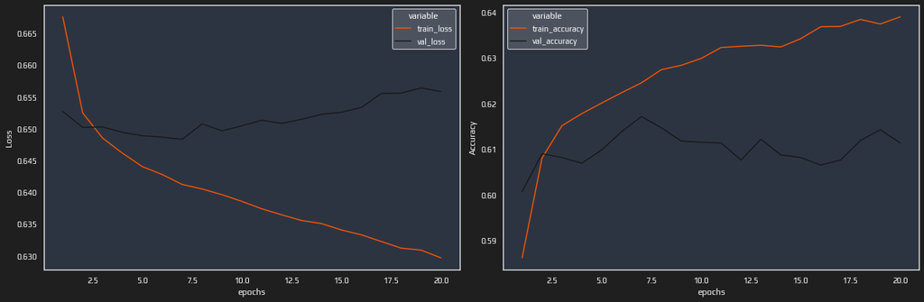

```python
nn_compare_train_val(history)
```

## Non-Overfit Model

```python
# Initializing Neural Network
nn = tf.keras.Sequential()
```

```python
# Adding input layer
nn.add(tf.keras.layers.Dense(64, input_shape=(len(X_train.columns),), activation="relu"))

# Adding hidden layers
nn.add(tf.keras.layers.Dropout(rate=0.5))
nn.add(tf.keras.layers.Dense(32, activation="relu"))
nn.add(tf.keras.layers.Dropout(rate=0.5))
nn.add(tf.keras.layers.Dense(16, activation="relu"))

# Adding output layer
nn.add(tf.keras.layers.Dense(1, activation='sigmoid'))
```

```python
# compile the model
nn.compile(optimizer='adam', loss='binary_crossentropy', metrics=['accuracy'])
```

```python
history = nn.fit(X_train, y_train, epochs=30, batch_size=100, validation_split=0.15, verbose=1)
```

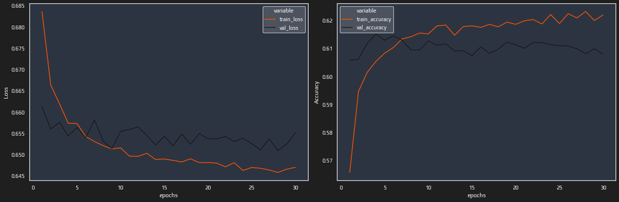

```python
nn_compare_train_val(history)
```

```python
# Evaluate the model
print_metrics_nn(nn, X_train, y_train, X_test, y_test)
```

Classification Report

|  | 0 | 1 | macro avg | weighted avg |
| --- | --- | --- | --- | --- |
| precision | 0.633297 | 0.599603 | 0.616450 | 0.616547 |
| recall | 0.554241 | 0.675326 | 0.614784 | 0.614432 |
| f1-score | 0.591138 | 0.635216 | 0.613177 | 0.613049 |
| support | 10398.000000 | 10278.000000 | 20676.000000 | 20676.000000 |

```
Train Accuracy: 0.6254		Test Accuracy: 0.6144
AUC Score: 0.6658857833775194
```

# Stacking Classifier

```python
estimators = list(zip(hyp_searches.keys(), [h.best_estimator_ for h in hyp_searches.values()]))
```

```python
stacking_clf = StackingClassifier(estimators=estimators, final_estimator=LogisticRegression(), cv=cv_folds)
```

```python
stacking_clf.fit(X_train, y_train)
```

[output not shown]

Classification Report

|  | 0 | 1 | macro avg | weighted avg |
| --- | --- | --- | --- | --- |
| precision | 0.621021 | 0.619521 | 0.620271 | 0.620275 |
| recall | 0.628486 | 0.611987 | 0.620237 | 0.620284 |
| f1-score | 0.624731 | 0.615731 | 0.620231 | 0.620257 |
| support | 10398.000000 | 10278.000000 | 20676.000000 | 20676.000000 |

```
Train Accuracy: 0.6340		Test Accuracy: 0.6203
```

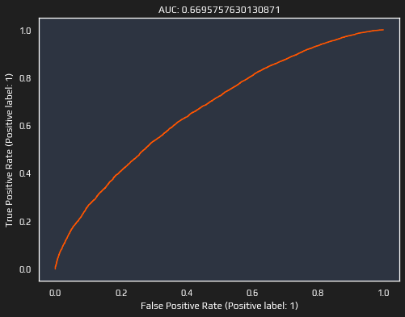

```python
print_metrics(stacking_clf, X_train, y_train, X_test, y_test)
```